# Python Visualizations

**by Giancarlo Marchesi**

This notebook explores commercial airplane flight delays in the United States from 2011 to 2020 using Matplotlib visualizations through the lenses of seasonality, airport traffic, and airline performance.

The dataset contains flight statistics for all airports in the United States. Each observation is reported by month, year, airport and airline. Flights can be categorized as ontime, delayed, cancelled or diverted. Flight delays are attributed to five causes: carrier, weather, NAS, security and late aircraft.

The data was downloaded from the Bureau of Transportation Statistics website https://www.transtats.bts.gov/OT_Delay/OT_DelayCause1.asp. The clean dataset contains 158,102 observations.

The analysis will solve the following questions using the mentioned visualizations

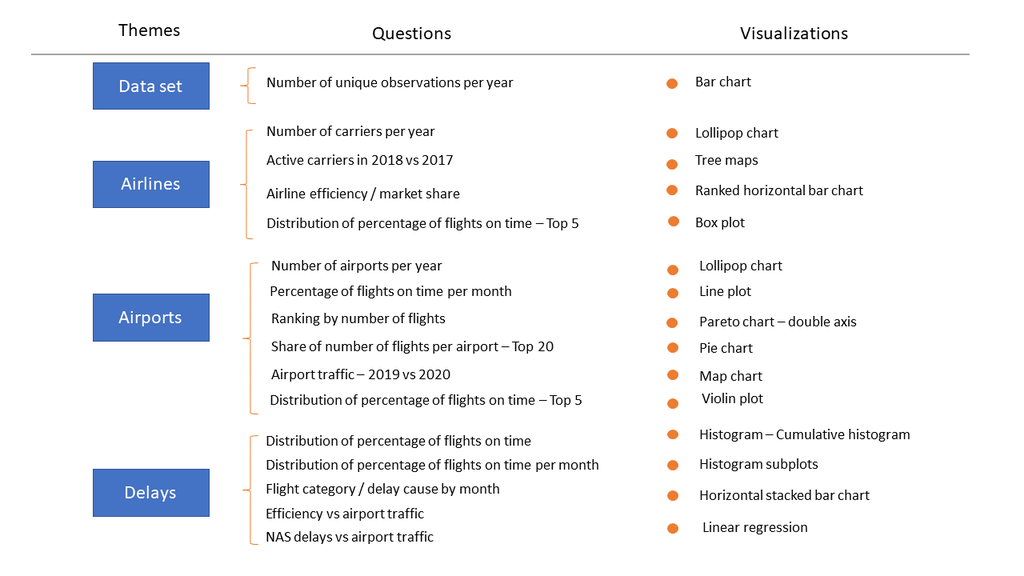

### Bar chart

Bar charts are a quick way to visualize the basics of a dataset. Let's begin by asking how many observations are in the dataset for each year.

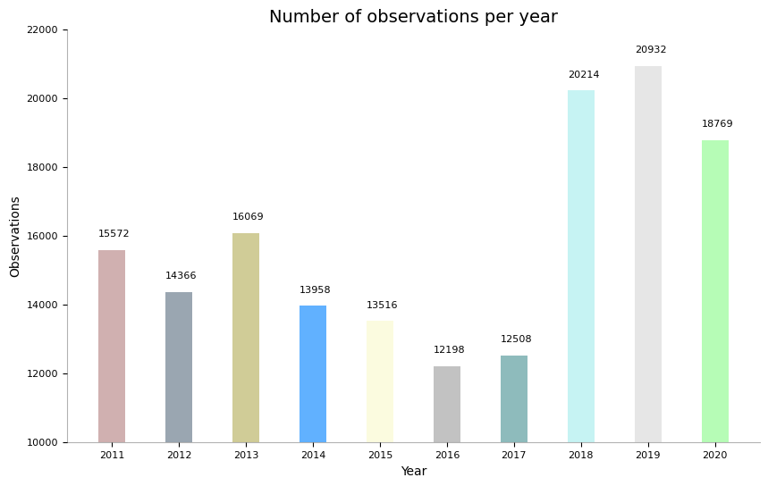

There is a very marked difference in the average number of observations per year between 2016-2017 and 2018-2020. Since each observation represents flights for each carrier, by airport, month and year, let's explore the following:

- The number of carriers over time
- The number of airports over time

### Lollipop chart

Lollipop charts are similar to bar charts. These can provide additional space if there are too many bars in the figure. It's not necessarily the case here, but let's introduce them for further reference.

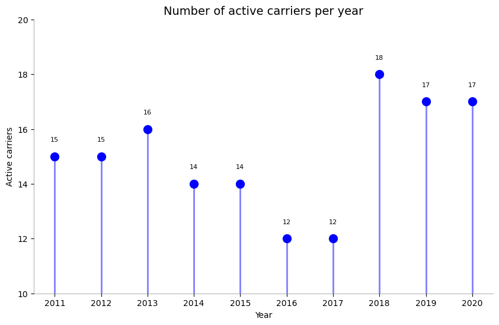

There are indeed fewer carriers in the years 2016 and 2017 than in the following years.

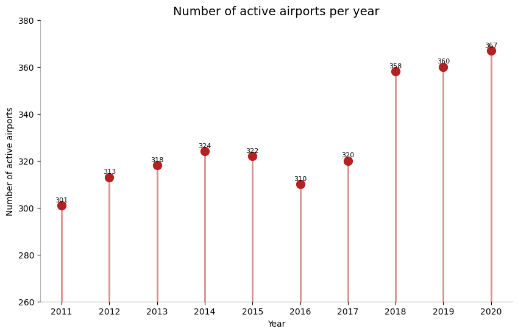

There is also an increase in number of airports int 2018-2020. So both effects are increasing the amount of observations after 2017.

### Tree maps

Tree maps are a convenient way to present the elements of a set, with an additional quantitative dimension like the percentage of observations in the set. In this case, its visual nature helps us figure out which are the new carriers in 2018.

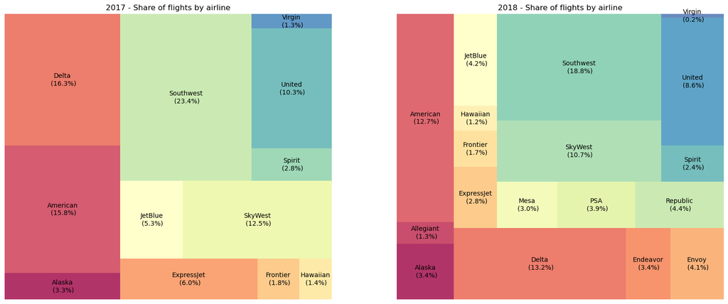

The new carriers introduced in 2018 are Allegiant, Endeavor, Envoy, Mesa, PSA & Republic

### Line plot

Line plots are the easiest way to see the trend of a variable over time. Let's start with the percentage of flights on time per month and year to look for trends. Is there seasonality? Has efficiency increased over time?

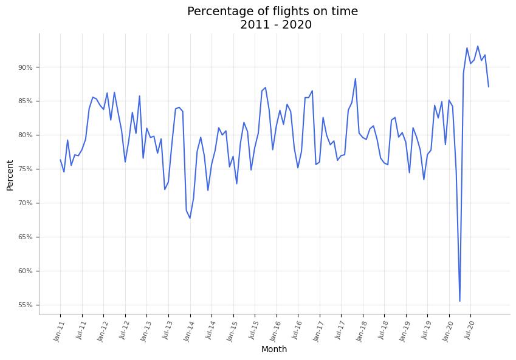

- The percentage of flights on time seems to oscilate around a mean of ~80%, so this point could be some seasonality. But what months are higher and lower than the mean?
- Also, 2020 is a clear outlier because of COVID. An upward trend would be tricky to confirm. The number of years are not enough, considering that 2020 is not really representative.

We want to figure out which months are above and below the mean. Lets introduce color as a variable for each of the four seasons. Let's add the name of the months in color to identify any pattern.

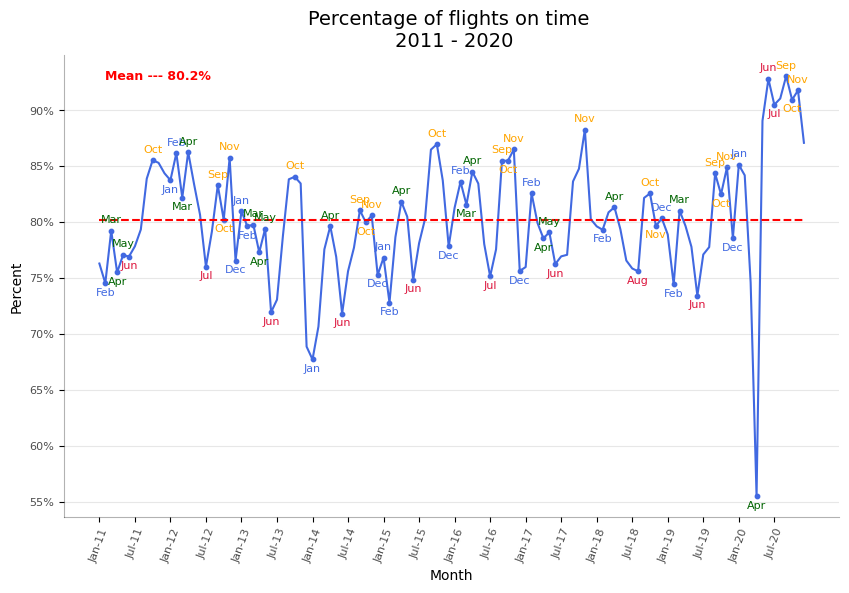

Now we see the prevalence of spring (green) and fall months (yellow) as the most efficient ones (i.e. March, April, September, October). On the contraty, summer and winter months are less efficient. This is expected because of high traffic in December holidays and bad weather in January and February. June is also the beginning of summer vacations and travel peaks during the 4th of July. 2020 is an anomaly because summer travel was curtailed by COVID restrictions and it appears to have been very efficient.

### Histograms

Histrograms show the distributions of variables. In this case, we want to know the distribution of flights on time for all aiports in the dataset, which includes data for all months and years they operated.

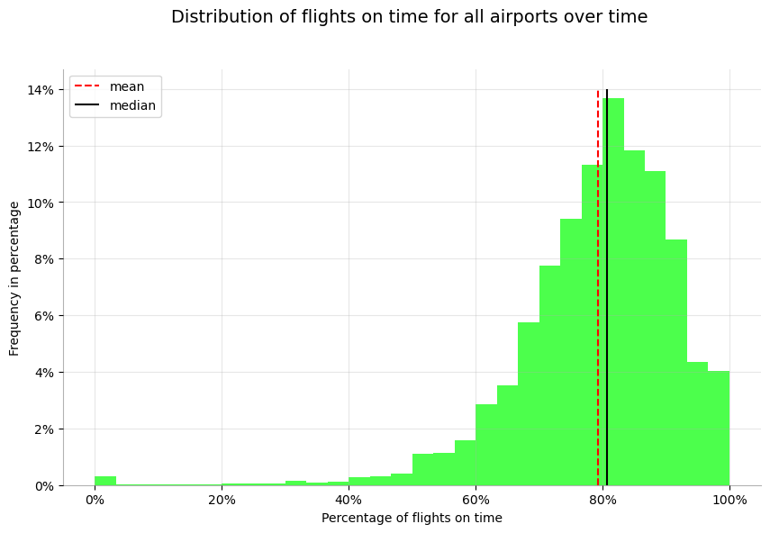

The distribution is not normal. Although, the mean and median are close to 80%, there is a long tail on the left, i.e. some aiports had very bad delay problems. Perhaps, this could be attributed to having very few flights or operated for short periods. We'll zoom into this phenomenon later in the analysis using other graphs.

#### Cumulative distribution of percentage of flights on time

This is another view of the same query. We see that the median monthly share of ontime flights hovers around 80%. Roughly more than 80% of observations' share of flights on time is higher than 70%.

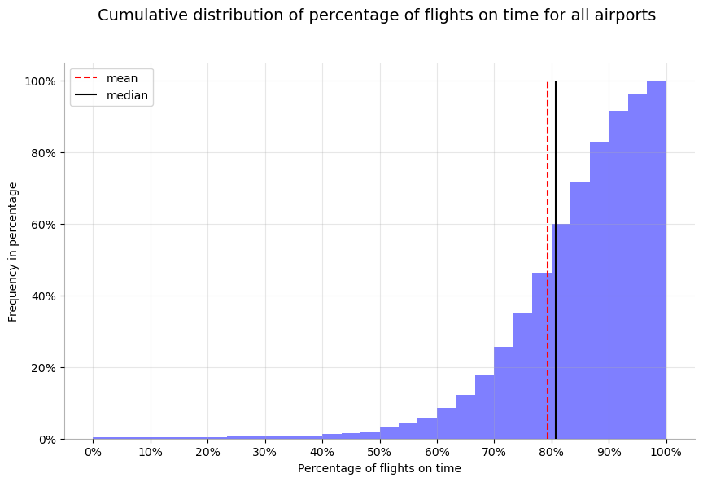

### Histogram subplots

We can use a subplot (4 rows, 3 columns) to check the distributions at the monthly level and calculate the means and medians.

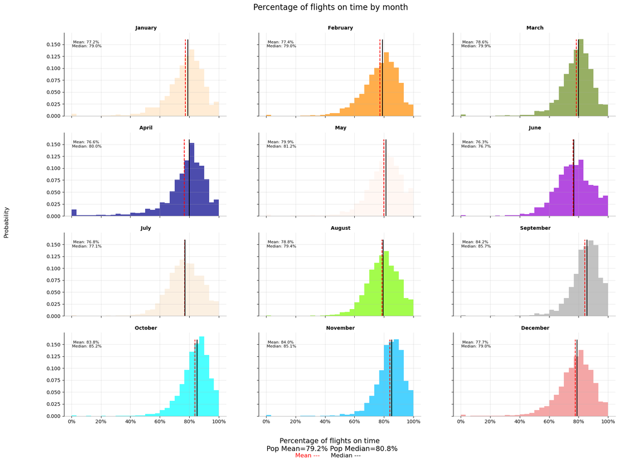

The mean of percentage of flights on time is 79.2%. It's slightly different than what we saw in an earlier calculation (80.2%) because, in this case, all airports are equally weighted, no matter the number of flights. Nevertheless, the conclusions are similar. The months of summer and winter have more delays than the months of spring and fall.

### Horizontal stacked bar chart

This bar chart shows the composition of a variable, in either relative or absolute terms, over time. In this example, the stacks add to 100% to understand how flight arrival categories and types of delays change from month to month in the sample.

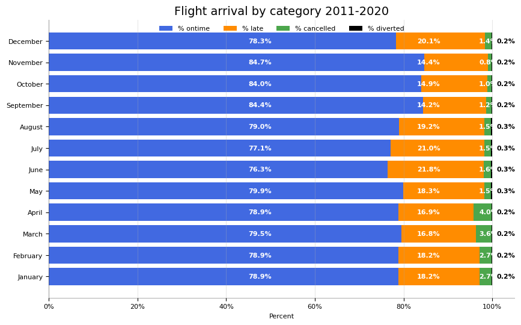

This is another view that gives us a similar conclusion to the previous slides. On average, the most efficient months are September, October and November, while June and July show the largest share of late flights. The largest percentage of cancelled flights occur in March and April. Diverted flights are about the same across all months.

Now, we want to know how the different causes for delays evolve during the year.

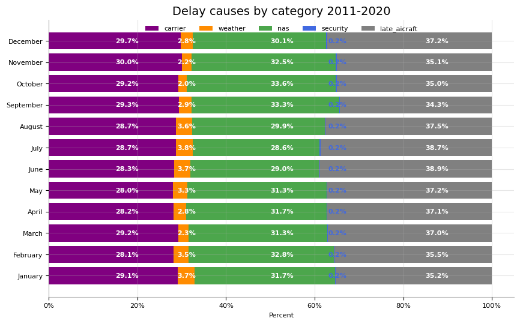

Late aircraft and carrier delays show similar numbers. They acount for roughly 65% of total delays. Aircraft are particularly late in the months of summer. NAS is at its highest during hurricane season (fall).

Delays or cancellations coded "NAS" are the type of weather delays that could be reduced with corrective action by the airports or the Federal Aviation Administration. Hence, they are separate from an expected "weather" event. During 2020, slightly less than half of NAS delays were due to weather according to the Bureau of Transport Statistics (BTS). Airport operations, heavy traffic volume, and air traffic control are other causes for NAS delays.

### Ranked horizontal bar chart

These charts provide a quick sense of the ranking of a variable. Which is the most efficient airline, i.e. the one with the highest share of flights on time? Which airline has the largest market share? How are these two variables related? Let's find out.

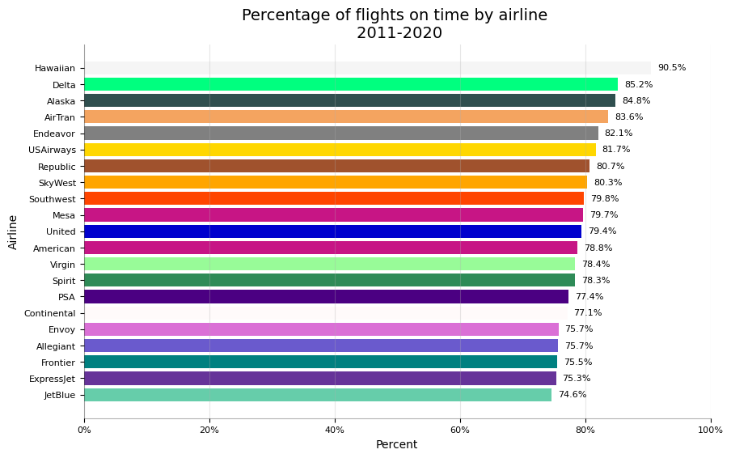

Hawaiian is the most efficient airline. Delta is in second place, despite being a major airline. How does this correspond with market share?

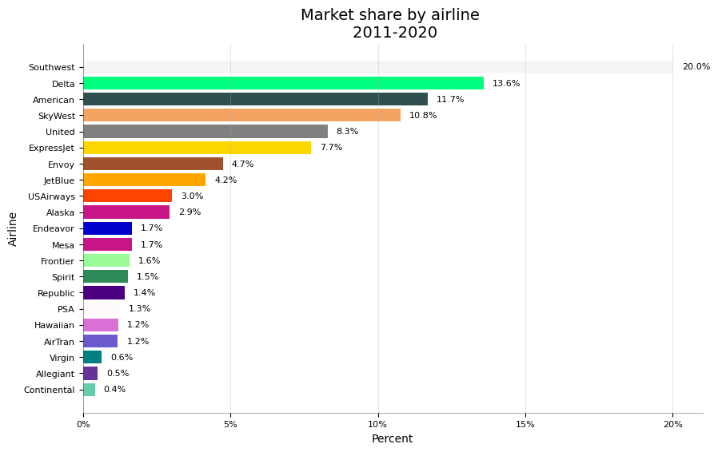

Delta has the best overall performance in terms of market share and efficiency. It's the second most efficient despite having the second largest market share. Southwest is the largest airline, but its efficiency is average. The other airlines in the top 5 in terms of efficiency are either small (Hawaiian, Airtran) or medium-sized (Alaska, Endeavor) carriers.

### Box Plot

Box plots are a great way to visualize the distribution, keeping the median, 25th 75th quartiles and the outliers in mind. In this case, we'll look at the distribution of percent of flights on time for the top 5 airlines by market share: Southwest, Delta, American, SkyWest and United.

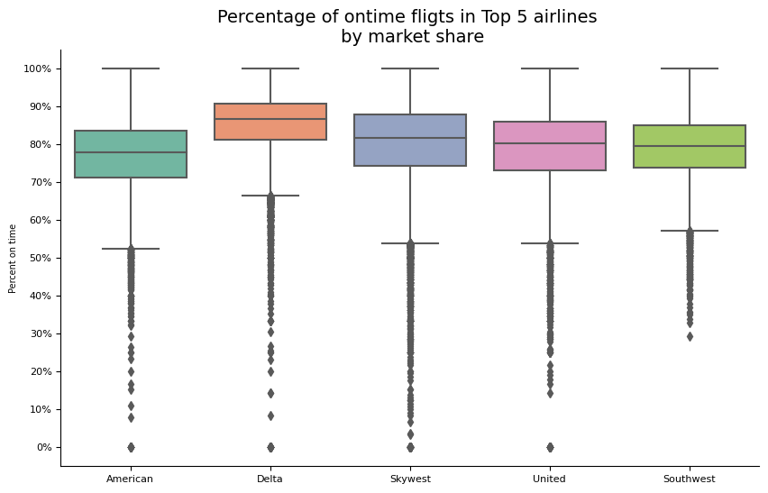

### Pareto chart - double axis

Pareto charts show how the elements of the set contribute to the cumulative distribution. Let's see how many airports contribute to 50% of the distribution, 80% and 95%.

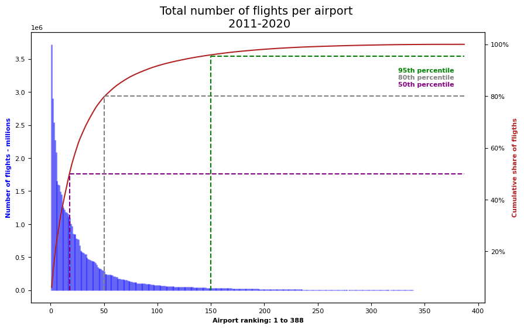

- 18 airports make 50% of total flights in the USA
- 50 airports make 80%
- 150 aiports make 95%.
- The rest 238 airports make the remaining 5%.
- From airport 300 to 388, the number of flights are so small they are no longer relevant to the scale of the figure

### Marginal Histogram

Marginal histograms have a histogram along the X and Y axis variables. This plot particularly useful for exploratory data analysis (EDA). In this case, let's compare airport efficiency vs size, i.e the percent of flights on time vs. it's market share by percentage of total flights.

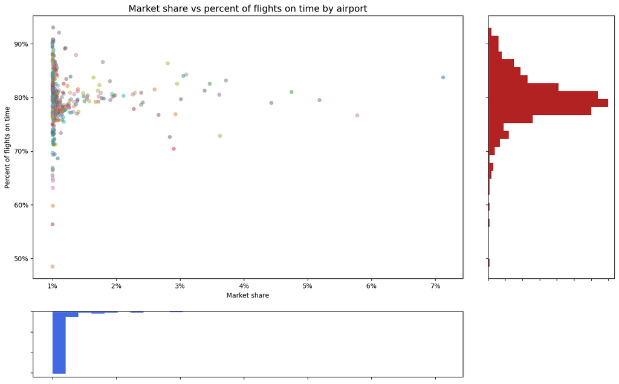

Most airports have an efficiency around 80% of flights on time and a market share of less than 1.5%.

### Pie charts

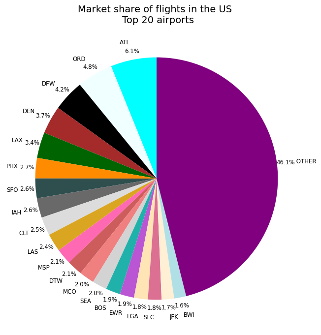

The top 20 aiports make 54% of the total market share. Atlanta (ATL) is the busiest airport, with Chicago (ORD), Dallas (DFW), Denver (DEN) and Los Angeles (LAX) rounding the top 5.

### Scatter plot

Scatteplots are used to study the relationship between two variables. In the case of multiple groups in the data, each group can be visualized in a different color. Let's analyze the relationship between percentage of flights on time an airport trafic among the top 20 aiports. The plot is divided into four zones, separated by the means of both variables: overperforming, underperforming, efficient and average.

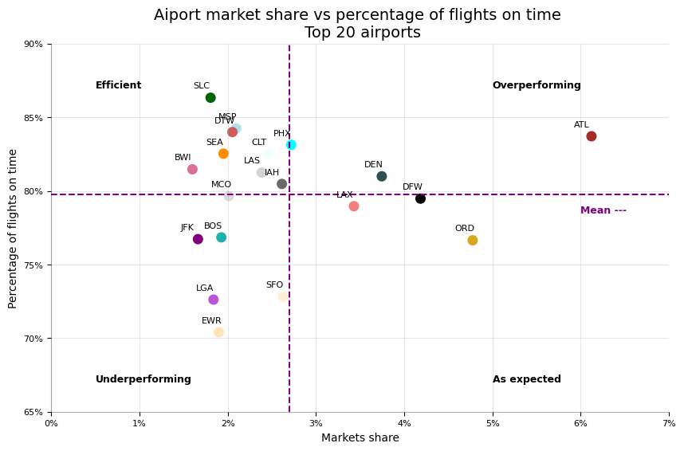

Salt lake city (SLC) is the most efficient airport among the top 20. Among the top 5 airports by market share, the best performing airport is Atlanta (ATL), with Denver (DEN) coming in second place. Los Angeles (LAX), Dallas (DFW) and Chicago (ORD) do as expected (similar market share as Denver and their mean performance is similar). Newark (ERW) is the worst performer among the top 20. Despite having a market share around the 2%, like most aiports, its efficiency is the lowest, nearing 70%.

### Violin plot

Violin plots are another way to visualize the distribution of a variable. The shape or area of the violin depends on the number of observations it holds. The median, 25th, 75th quartiles and the outliers can be marked inside the figure. In this case, we'll look at the distribution of percent of flights on time for the top 5 airports by market share: ATL, DEN, LAX, DFW and ORD.

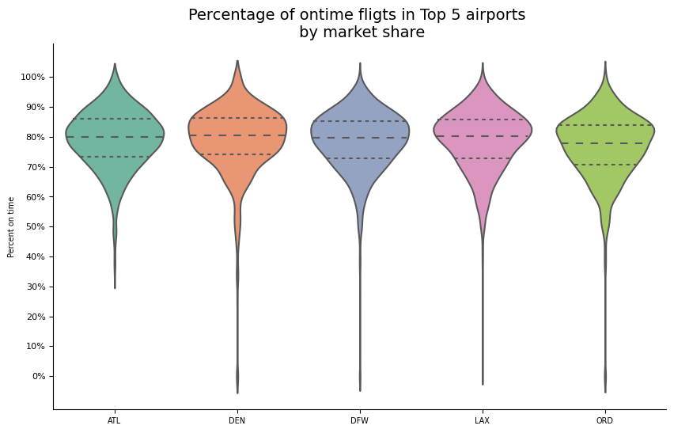

Although the medians of the 5 airports are pretty close, Atlanta's distribution has a shorter tail and is thicker in the third quartile, which is why it's average (like we saw in the previous scatterplot) is higher than the other four. Denver's shape is the closest to ATL's, yet it has a longer tail and, hence, a lower average.

### Map Chart

Let's use the longitude and latitude of the top 10 aiports to see the changes between a non-COVID year (2019) and 2020. I will use the geopandas library to graph them on a map of the US.

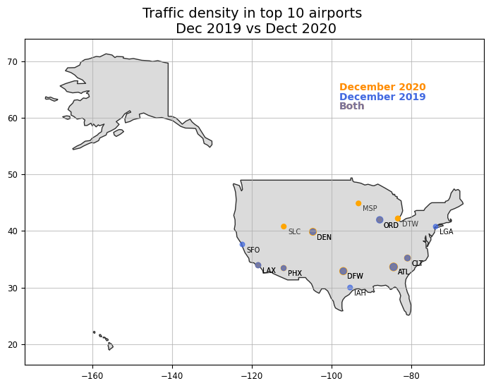

We see that LGA, SFO and IAH were replaced in 2020 by Salt Lake City (SLC), Minneapolis (MSP) and Detroit (DTW) during the COVID restrictions. This is expected because of the international travel restrictions and more stringent restrictions enacted in NY, San Francisco and Houston during the pandemic. Local tourism and holiday travel suffered.

### Linear regression

Regression is a parametric technique used to predict a dependent variable given one or a set of independent variables. Let's find out if there are statistically significant relationships between airport traffic and efficiency and the latter with NAS delays.

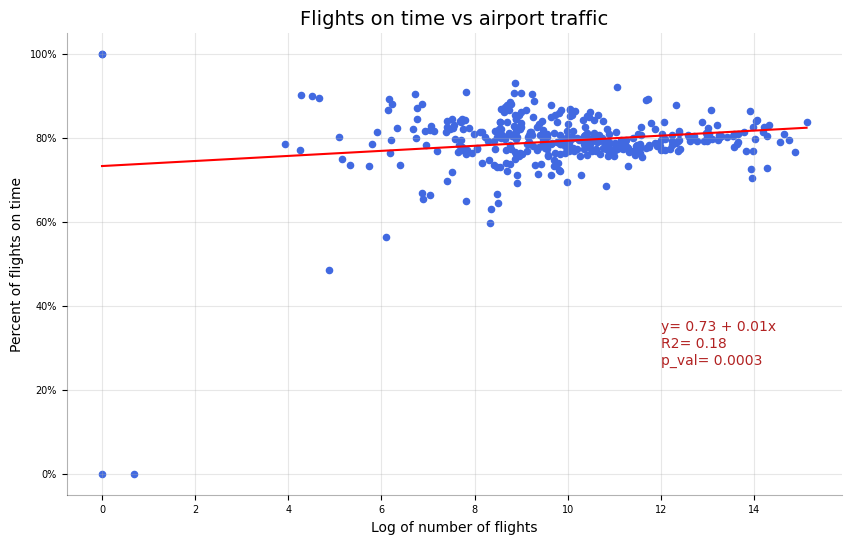

Size appears to have a positive effect on airport efficiency, as measured by percent of flights on time. Although the R2 isn't large, the p_value shows that size does have a statistical effect on efficiency at the 95% confidence level. However, there are some outliers at the bottom of the size distribution that might skew the results. Let's focus on a first set of Log number of flights, bewteen 4 and 11.

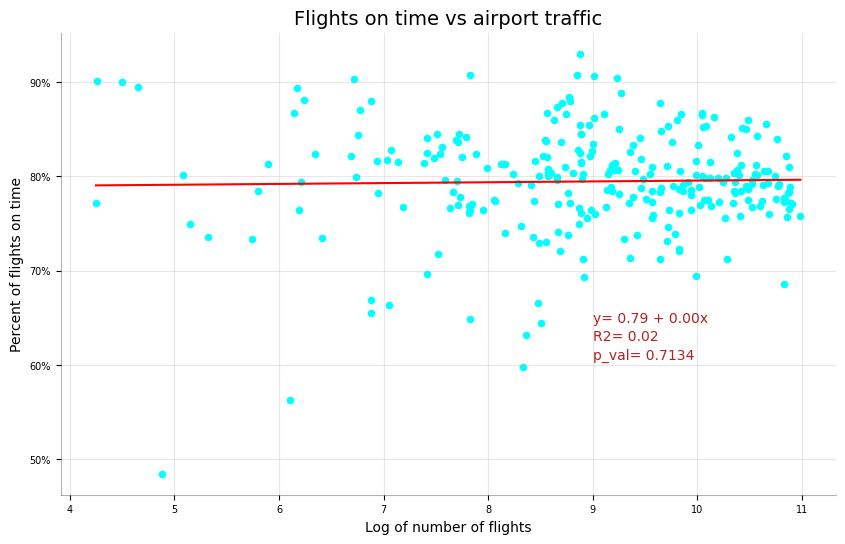

In the case of medium-sized airports, once the outliers are taken out, there is no statistically significant relationship between number of flights and efficiency. The relationship seems to be random.

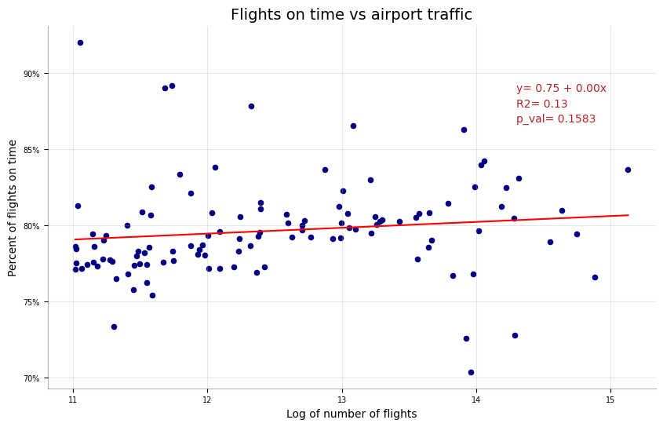

For larger airports, there is also no significant difference in efficiency due to size. The p-value is above the threshold level at the 95% level and the R2 is fairly low.

Hence, when outliers are taken out, there seems to be no significant relationship between the two variables at any level. What's the relationship between NAS delays vs. airport traffic?

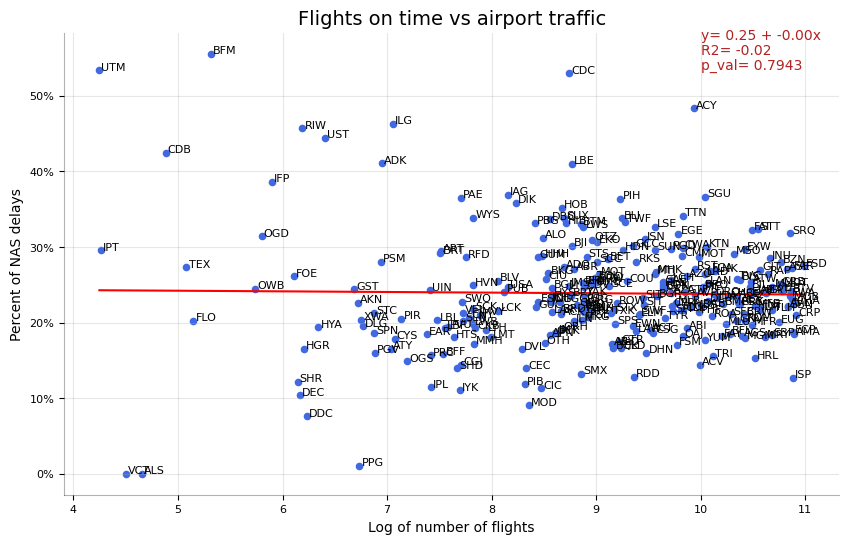

There doesn't seem to be a relationship between percent of nas delays and size of the aiport for medium-sized airports. The p-value is above the statistically significant threshold. The R2 is very low.

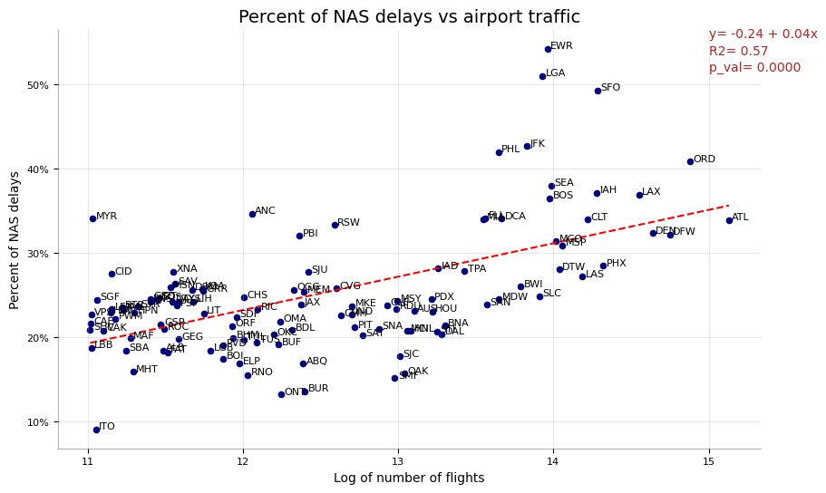

We see quite a few of the larger airports above the regression line: EWR-Newark (New Jersey), LGA-La Guardia (New York), SFO-San Francisco, ORD-Chicago, JFK-NewYork, PHL-Philadelphia, SEA-Seatle, BOS-Boston, IAH-Houston, LAX-Los Angeles. Also, the p-value is 0, which means it's below the thresh significance level. Hence, the relationship is statistically significant.

In conclusion, there is some evidence to support the hypothesis that larger airports tend to have higher percentage of NAS delays. These, according to BTS, could be reduced with corrective action by the airports or the Federal Aviation Administration.